# Beyond Language Barriers

Can LLMs Analyze Sentiment in French Text?

Laurence-Olivier M. Foisy

mail@mfoisy.com

Université Laval

Camille Pelletier

Étienne Proulx

Sarah-Jane Vincent

Mickael Temporão

Yannick Dufresne

April 4, 2025

## Research Journey

- Studying media discourse on **Open Source Software** in French.
- Corpus: **2,683** news articles (1995-2025).
- Needed: **Sentiment Analysis** over time.
- Traditional tool: Lexicoder Sentiment Dictionary (LSD).
- *The thought:* What if we used **Large Language Models (LLMs)** instead?

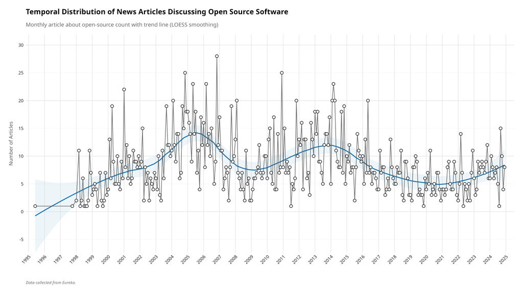

## The Challenge: LLMs & Language

### Most Foundational LLMs

- Predominantly trained on **English** data.
- Performance in other languages? Less certain.

### Our Research Questions

1. Can **general-purpose LLMs** accurately evaluate sentiment in French texts **without fine-tuning**?
2. How do **open-source** LLMs perform compared to closed-source?
3. Does the **language of the prompt** (French vs. English) affect performance?

## Why Does This Matter?

**For Social Science Research:**

- **Scale Up Analysis:** Handle larger datasets.
- **Lower Barrier:** Less ML expertise needed.
- **Capture Nuance:** Go beyond dictionary limits (potentially).
- **Analyze Multilingually:** Work directly with non-English text.
- **Process Locally:** Enhance privacy with open models.

**Broader Impact:**

- **Advance Multilingual Tech:** Reduce English bias in NLP.
- **Integrate AI Methods:** Adapt new tools for research.
- **Understand AI Capabilities:** Evaluate influential technology.
- **Democratize Tools:** Broaden access to advanced NLP.

## The Literature Gap

**What We Knew:**

- Specialized models work.
- Fine-tuning helps.
- English prompts *might* aid cross-lingual tasks.

**What We Didn’t Know:**

- **General** LLMs w/o fine-tuning?
- **Open-source** vs. closed?
- Impact of **prompt language** for French?
- LLMs vs. **dictionaries**?

## Approach: Systematic Evaluation

**Data**

- French News Corpus
- 200 annotated sentences
- Google Translate
- Manual Annotation (-1 to 1)

**Methods**

- **11 LLMs** (Open/Closed)
- **3 Linguistic Conditions**
- **19,800** Prompts
- Compared: Lexicoder Dictionaries
- Metrics: Corr, MAE, F1 (3/7 cat)

## Before We Begin:

### Warning:

- Take the results with a grain of salt.
- Only 200 sentences
- Single coder

[figure not shown]

## The Contenders: 11 LLMs

**Closed Source:**

- Anthropic: Claude 3.5 Haiku
- Google: Gemini 2.0 Flash
- DeepSeek Chat
- OpenAI: GPT-4o

**Open Source (Weights):**

- Meta: Llama 3.2 (1B, 3B)
- Google: Gemma 2 (9B)
- Mistral: Saba (24B)
- Ali Baba: QWQ (32B)
- Meta: Llama 3.3 (70B)
- DeepSeek R1 Basic (671B)

## The Experiment

[figure not shown]

## Prompt Structure

```markdown
Please analyze the sentiment of the following French text and provide a single
numerical rating according to this scale:

Sentiment Scale:
-1.0: Strong negative sentiment...
// ... (Scale definitions) ... //
 1.0: Strong positive sentiment...

Important instructions:
1. ...consider cultural and linguistic nuances...
2. ...analyze emotional tone, word choice...
3. Respond ONLY with a single numerical value...
4. Do not include ANY explanations...

Here is the text to analyze: [TEXT]
```

## Finding 1

### LLMs can analyze sentiment in French

**Key Points:**

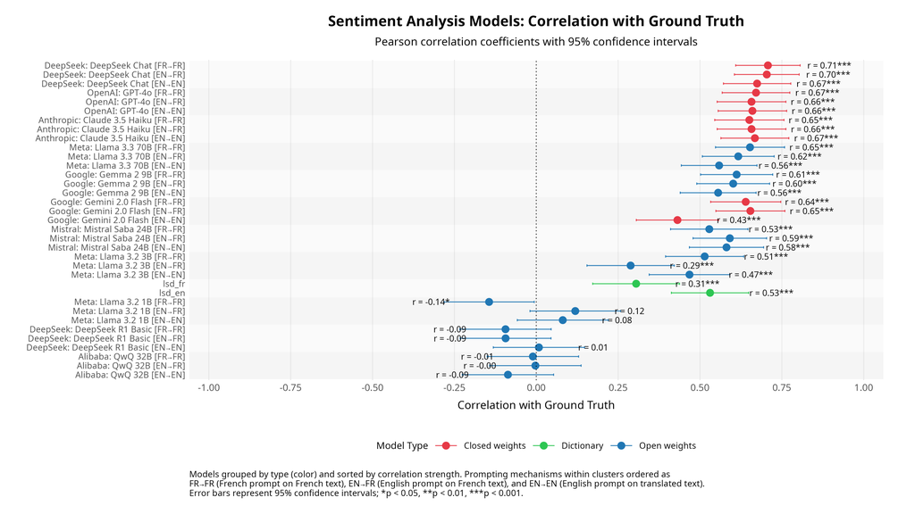

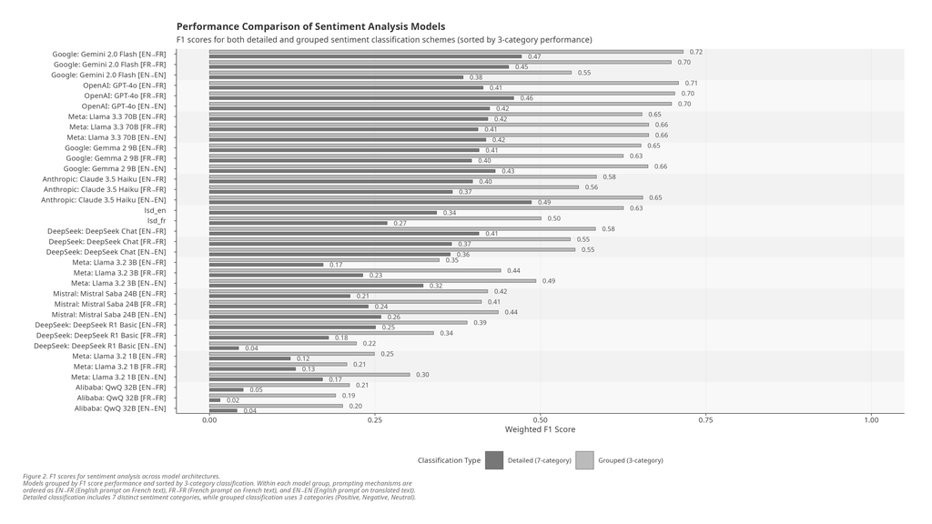

## Finding 2

### minimal practical impact of prompt language choice.

| Condition | Avg. Corr | Avg. F1 (3-cat) | Avg. MAE (Lower is Better) |
| --- | --- | --- | --- |
| **FR → FR** | 0.537 | 0.539 | 0.260 |
| **EN → FR** | **0.543** | 0.546 | 0.259 |
| **EN → EN** | 0.520 | **0.557** | **0.252** |

- Differences between prompt/text language conditions are consistently small across all metrics.
- No single condition consistently outperforms others:
  - EN→FR leads slightly in Correlation.
  - EN→EN leads slightly in F1 scores and has the lowest avg. error (MAE).

## Finding 3

### LLMs vs. Dictionary

**Correlation (Nuance):**

- 🥇 **Top LLMs Win:** Better intensity capture (r=0.71).
- 🥈 LSD Baseline: Less nuanced (EN r=0.53).

**F1 Score (3-Cat Polarity):**

- 🥇 **Top LLMs Win (narrowly):** F1 ≈ 0.71.
- 🥈 **EN LSD Very Competitive:** F1 = 0.625!

**Insight:** LLMs better for *intensity*, but LSD holds its own for basic *polarity* and offers **transparency**.

## Finding 4

### Bigger parameters size is better

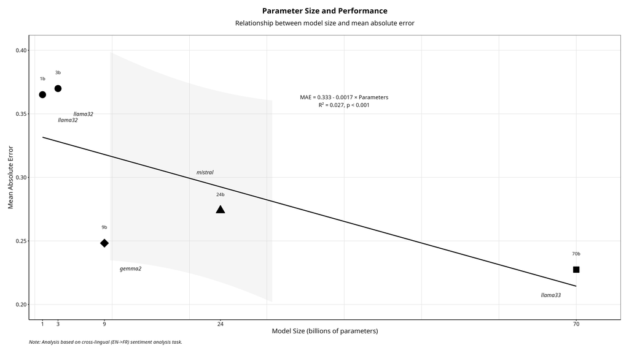

## Finding 5

### Dictionaries are still strong

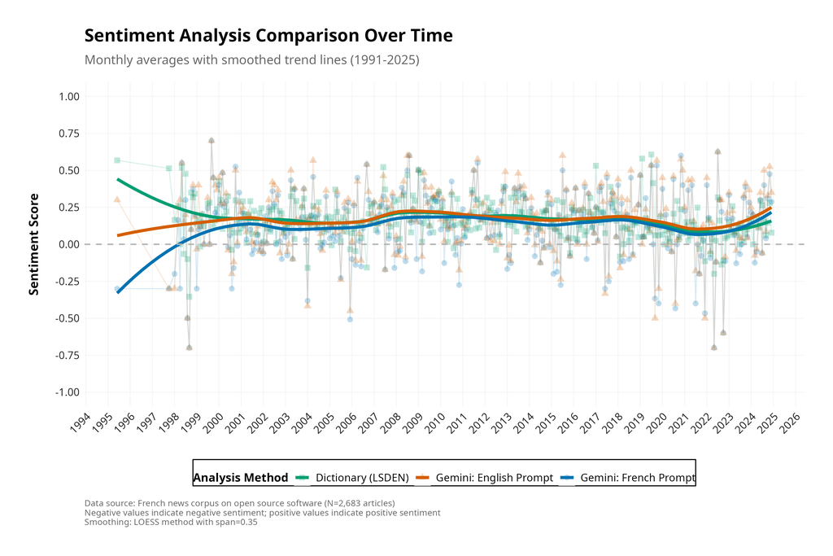

## Keep In Mind: Limitations

**Data & Scope Caveats:**

- **Ground Truth Reliability:**
  - Single coder (No Inter-Annotator Agreement)
  - Small validation sample (200 sentences)
  - May not capture full linguistic variety
- **Generalizability Limits:**
  - French language only (Not other languages)
  - Specific domain/genre (News / Open Source)

**Method & Context Caveats:**

- **Methodological Factors:**
  - Translation quality (Google Translate) not assessed
  - Fixed prompt structure (Model-specific tuning?)
  - Inconsistent LLM output formats (Parsing needed)
- **Study Parameters:**
  - LLM selection based on accessibility/cost
  - No efficiency analysis (Time/Cost)
  - Snapshot in time (Rapid LLM evolution)

## Conclusion

**Can general-purpose LLMs analyze sentiment in French without fine-tuning?** **Yes.**

**The Bottom Line:** Choose based on **nuance vs. transparency**. LLMs are valuable tools for non-English text.

## Thank You!

**Questions?**

Laurence-Olivier M. Foisy

`mail@mfoisy.com`

*Co-authors: Camille Pelletier, Étienne Proulx, Sarah-Jane Vincent, Mickael Temporão, Yannick Dufresne*

*Full paper/details available in [GitHub](https://github.com/clessn/mpsa_beyond_language)*

[figure not shown]

LLMs for French Sentiment Analysis | https://mfoisy.com